# JUb19 as donor versus all other recipients

# Data formating from pairwise competition

Compile data from different competition assays (JUb19 as donor and other species as recipient) at start (0 hr) and end (24 hr) points (under OD = 1).

| strain | replicate | D0 | R0 | logD0 | logR0 | D24 | R24 | logD24 | logR24 |
| --- | --- | --- | --- | --- | --- | --- | --- | --- | --- |
| BIGb0170 | 1 | 1.34e+10 | 4.80e+09 | 10.127105 | 9.681241 | 2.84e+12 | 2.08e+11 | 12.45332 | 11.318063 |
| BIGb0170 | 2 | 1.11e+10 | 5.70e+09 | 10.045323 | 9.755875 | 1.96e+12 | 1.60e+11 | 12.29226 | 11.204120 |
| BIGb0170 | 3 | 9.70e+09 | 4.40e+09 | 9.986772 | 9.643453 | 2.52e+12 | 2.28e+11 | 12.40140 | 11.357935 |
| BIGb0170 | 4 | 1.20e+10 | 6.70e+09 | 10.079181 | 9.826075 | 2.28e+12 | 2.28e+11 | 12.35793 | 11.357935 |
| BIGb0170 | 5 | 7.40e+09 | 6.10e+09 | 9.869232 | 9.785330 | 2.20e+12 | 2.56e+11 | 12.34242 | 11.408240 |
| BIGb0170 | 6 | 1.02e+10 | 6.50e+09 | 10.008600 | 9.812913 | 2.24e+12 | 2.40e+11 | 12.35025 | 11.380211 |
| BIGb0172 | 1 | 1.64e+10 | 2.40e+09 | 10.214844 | 9.380211 | 3.52e+12 | 2.72e+10 | 12.54654 | 10.434569 |
| BIGb0172 | 2 | 1.28e+10 | 1.90e+09 | 10.107210 | 9.278754 | 3.28e+12 | 2.96e+10 | 12.51587 | 10.471292 |
| BIGb0172 | 3 | 1.47e+10 | 2.00e+09 | 10.167317 | 9.301030 | 4.08e+12 | 2.28e+10 | 12.61066 | 10.357935 |
| BIGb0172 | 4 | 9.50e+09 | 3.80e+09 | 9.977724 | 9.579784 | 3.24e+12 | 1.76e+10 | 12.51055 | 10.245513 |

[output cut: 56 more lines]

# Frequency lineplot (JUb19 vs others)

Here, as a first attempt to visualize the competitive outcome, we plot the frequency change across 0 and 24 hrs. The first figure shows the frequency change for JUb19 (donor) and the second mirrored figure shows that for the other species (recipient).

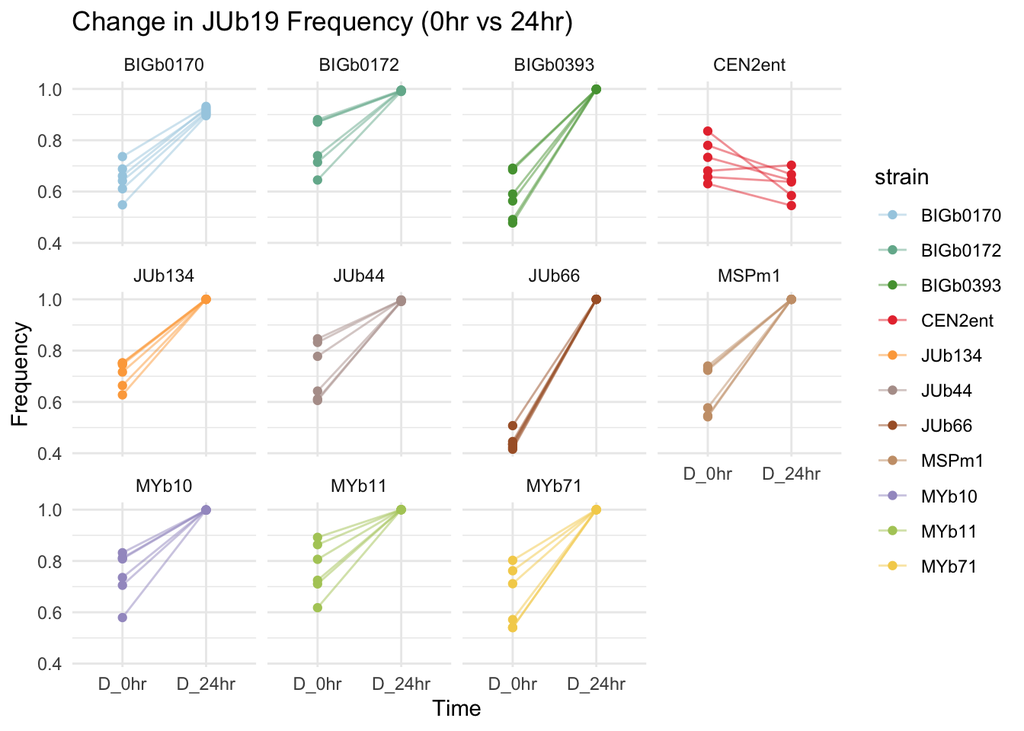

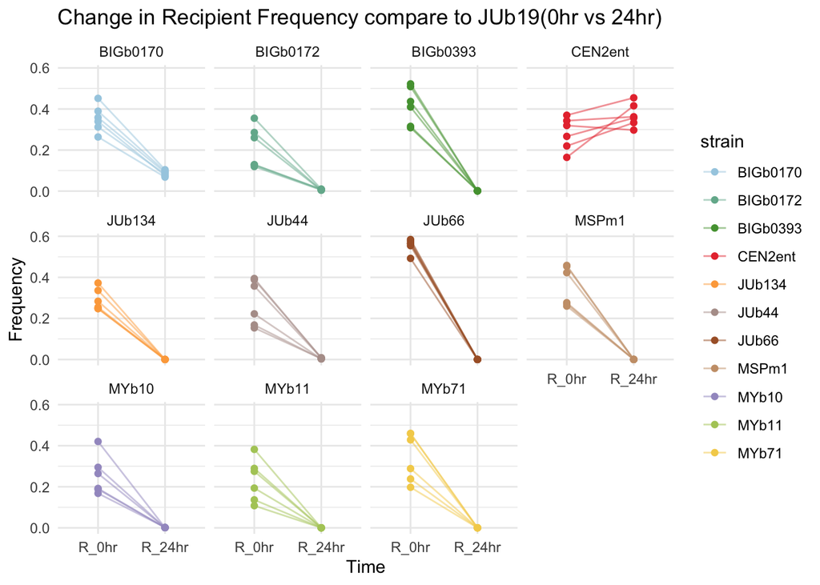

# Interspecies competition value between donor and recepient (JUb19 vs others)

Again, consider a Lotkta–Volterra competition model in the form of $\frac{dN_i}{dt} = N_i(r_i-\alpha_{ii}N_i-\alpha_{ij}N_j)$. While we used a statistical fitting approach to estimate the intraspecific competition coefficients ($\alpha_{ii}$H), we cannot do that for the interspecific competition coefficients ($\alpha_{ij}$) due to the lack of a density gradient (but see the results for Jub19 and CEN2ent in a separate file). Instead, we use a “hybrid” approach. Here, in the Lotka–Volterra competition model, the per capita growth rate is still estimated as $\frac{\Delta lnN_i}{\Delta t}$, and the species’ $r_i$ and $\alpha_{ii}$ are obtained by the previous statistical fitting results for the monoculture growth assay (i.e., $\hat{r_i}$ and $\hat{\alpha_{ii}}$). By rearranging the equation, we can indirectly obtain an esitmate for the interspecific competition coefficients as follows:
$$\alpha_{DR} =
\left[\hat{r_D}-\hat{\alpha_{DD}}N_{D0}^c-\left(\frac{lnN_{D24}^c -
lnN_{D0}^c}{24}\right)\right].\left(\frac{1}{N_{R0}^c}\right)$$
$$\alpha_{RD} =
\left[\hat{r_R}-\hat{\alpha_{RR}}N_{R0}^c-\left(\frac{lnN_{R24}^c -
lnN_{R0}^c}{24}\right)\right].\left(\frac{1}{N_{D0}^c}\right)$$
, where $N_{jt}^c$ represents the scaled population size of species $j$ (= $D$ of $R$) at time $t$ (= 0 or 24 hr) within the co-culture (superscript $c$). Note again all density data were scaled by $10^9$ prior to calculation. Below, we show (left) the estimated effect of other recipient species of JUb19 ($\alpha_{DR}$), and (right) the estimated effect of JUb19 on the other recipient species ($\alpha_{RD}$, with $D$ = JUb19). Indeed, most species are heavily impacted by JUb19 except CEN2ent.

[output not shown]

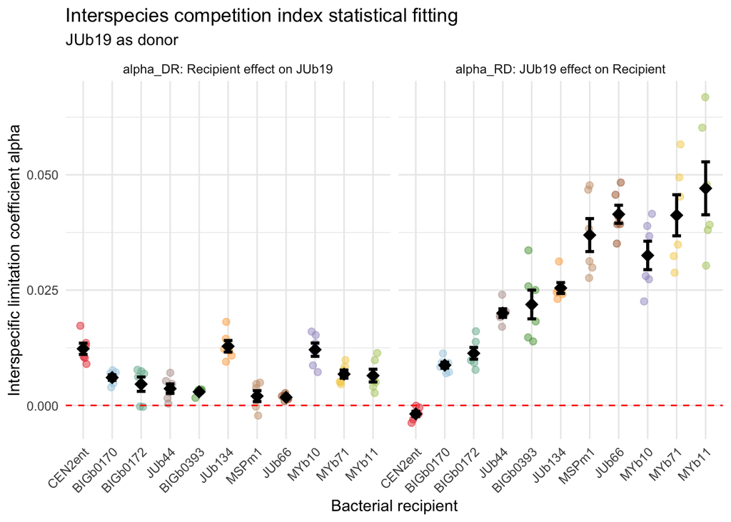